# STAT 380 Final Project

Isaac Swope

Andrew Loiselle

2026-04-23

## Task 1 (Data Cleaning and Data Visualization – Complete without Generative AI)

Research Question: Which maps are the most likely to win the map vote when they are an option?

First it is necessary to bind each of the two player’s data sets into one data frame we will call `Games`. From `Games`, the column `MapVote` is separated into `Map1Vote` and `Map2Vote`. Now ties can be filtered out where the two map options have an equal number of votes. The map names are set to all lowercase and extra spaces are removed in both our new data frame called `Games_votes` and the map reference data frame called `Maps`. This way instances with misspelled names will removed, but instances with differing capitalization and spacing will be preserved by eventually joining these two data frames. The frequencies of a map appearing as either `Map1` or `Map2` are added together to get the total ammount of times a map has appeared as a candidate. The total vote wins for each map are then joined to the table, and the win frequency is calculated by dividing the win count for each my by its candidate count. Below we can see the table showing the number of times a map has appear as a candidate, the number of times it won the vote, and the proportion of votes it won.

| map | candidate_count | vote_win | vote_win_proportion |
| --- | --- | --- | --- |
| amerika | 21 | 13 | 0.6190 |
| apocalypse | 51 | 17 | 0.3333 |
| armada strike | 38 | 8 | 0.2105 |
| cartel | 52 | 14 | 0.2692 |
| checkmate | 46 | 29 | 0.6304 |
| collateral strike | 40 | 26 | 0.6500 |
| crossroads strike | 52 | 41 | 0.7885 |
| deprogram | 32 | 8 | 0.2500 |
| diesel | 50 | 35 | 0.7000 |
| drive-in | 39 | 22 | 0.5641 |
| echelon | 39 | 6 | 0.1538 |
| express | 52 | 34 | 0.6538 |
| garrison | 44 | 15 | 0.3409 |
| hijacked | 39 | 22 | 0.5641 |
| jungle | 12 | 3 | 0.2500 |
| miami | 23 | 2 | 0.0870 |
| miami strike | 47 | 21 | 0.4468 |
| moscow | 58 | 24 | 0.4138 |
| nuketown ’84 | 32 | 27 | 0.8438 |
| raid | 38 | 32 | 0.8421 |
| rush | 39 | 22 | 0.5641 |
| satellite | 31 | 13 | 0.4194 |
| slums | 35 | 23 | 0.6571 |
| standoff | 42 | 30 | 0.7143 |
| the pines | 57 | 25 | 0.4386 |
| wmd | 10 | 2 | 0.2000 |
| yamantau | 62 | 28 | 0.4516 |
| zoo | 39 | 18 | 0.4615 |

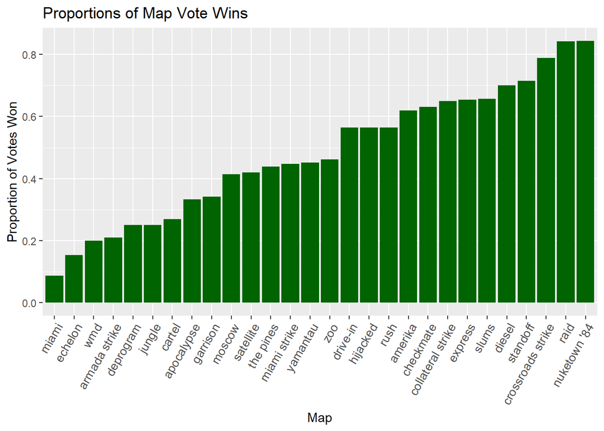

From the above plot of proportions of votes won for each map, we can see that `raid` and `nuketown '84` are the maps that are most likely to win the map vote when they are an option, each with a probability greater than 80%.

## Task 2 (Data Cleaning and Data Visualization – Complete using Generative AI)

For this section of the report, we chose to use Microsoft Copilot. We gave copilot the same information that was given to us in the project information sheet, which we included in the first promt. We told the AI the names of the datasets and their variables, the relevant information at the start of task 1, and the research question from task 1. After this, we gave the AI some of the notes provided in task 1, such as “To do this, you will have to calculate the number times that each map was listed as a candidate (Map1 or Map2) and earned more votes than the other candidate. …You should also include a visualization of the results.” This section of the notes clearly lays out a few steps that it would have to follow to thoroughly answer the research question and male sure that it followed the same baseline that we did in task 1. After this, we told the AI: “Use R and generate code to answer the research question. Feel free to clean the code in a way that makes the most sense. Assume the data has already been read in as named above”. This way, Microsoft Copilot would complete this task in a readble format that I could apply to R. It also made sure that the code it generated was usable with the data we had already read in, as I informed the AI of the names we gave the data when we read it in in task 1.

The AI generated a 6 step solution including code that is implemented below. The steps were: 1. Combine and clean the datasets 2. Determine whether Map1 or Map2 won the vote 3. Reshape data so each row corresponds to a map being an option 4. Compute wins and appearances 5. Print the summary table 6. Visualization

```
## # A tibble: 46 × 4
##    Map                    appearances  wins win_rate
##    <chr>                        <int> <int>    <dbl>
##  1 Nuketown '84 Halloween           1     1    1
##  2 Nuketown '84                    39    32    0.821
##  3 Crossroads Strike               58    45    0.776
##  4 Raid                            42    32    0.762
##  5 Standoff                        47    33    0.702
##  6 Diesel                          55    37    0.673
##  7 Slums                           41    27    0.659
##  8 Drive-In                        28    18    0.643
##  9 Express                         62    39    0.629
## 10 Checkmate                       55    34    0.618
## # ℹ 36 more rows
```

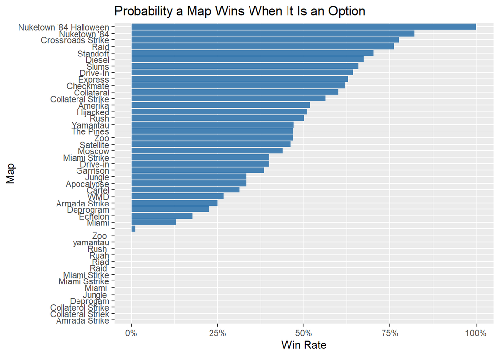

Our solution from Task 1 and the generative AI solution are similar, as they both aim to estimate, for each map, the probability that it wins when it is an option, and both do so by counting appearances as a candidate and wins as the chosen map. Structurally, they both combine Player 1 and Player 2 data, work at the match level, aggregate to the map level, and present a table and a bar plot of win proportions. Our use of candidate_count, vote_win, and vote_win_proportion are similar to Microsoft Copilots appearances, wins, and win_rate, and both outputs rank maps in a way that highlights consistently popular ones like Nuketown ’84, Raid, Crossroads Strike, and Standoff.

The most important difference is how ties are handled. In Our solution, we explicitly filter out all matches where Map1Vote == Map2Vote, which removes tied votes from both the wins and candidate appearances. This means that when a map wins because it is listed as Map1 in a tie, that win is not counted at all. Microsoft COpilots solution, by contrast, keeps those matches and assigns the win to Map1 whenever Map1Vote == Map2Vote, which is more in line with the problem statement: “In the event of a tie vote, the map listed in Map1 is chosen.” As a result, the generative AI table shows higher appearance and win counts for maps that frequently appear as Map1, and slightly lower win rates in some cases because the denominator, candidate appearances, is larger. From the standpoint of faithfully representing how the game actually chooses a map, the tie-inclusive approach is more correct, because a tie is not a “missing outcome” but a real win for Map1.

A second key difference lies in robustness and data handling. Our approach standardizes map names to lowercase and remove extra spaces, and we join to the Maps reference table so that your final output is aligned with the official map list. However, our logic for counting candidates and wins is more fragmented, as we compute Option1, Option2, and OptionWin separately and then stitch them together with full_joins on different keys. This works, but it’s relatively brittle. If there were more complex patterns like missing values or additional map fields, the joins could become harder to reason about. The generative AI solution uses a pivot-longer style that treats each map-option row uniformly, which tends to be easier to extend and less error-prone when the data structure evolves.

Another meaningful difference between the two solutions lies in how clearly each analysis communicates its logic and how easily another analyst could reproduce or audit the results. Our solution is highly transparent in the sense that each step—splitting votes, filtering ties, counting Map1 and Map2 appearances separately, and joining the results—is explicitly laid out. This makes it easy for a reader to follow our reasoning and understand exactly how each intermediate object contributes to the final table. However, because ties are removed early in the workflow, the meaning of the final win proportions subtly shifts, but this shift is not immediately obvious from the table alone. A reader unfamiliar with our filtering choice might assume the proportions reflect all matches, including ties, which could lead to misinterpretation. The generative AI solution, by contrast, uses a more compact and expressive data‑reshaping strategy that makes the analytical logic easier to verify at a glance. This alignment between data structure and research question enhances reproducibility because the transformation steps correspond cleanly to the conceptual steps.

## Task 3 (Inference)

Research Question: How does the game type affect TotalXP after accounting for the Score?

```
## # A tibble: 4 × 6
##   GameType_clean     n mean_TotalXP sd_TotalXP mean_Score sd_Score
##   <chr>          <int>        <dbl>      <dbl>      <dbl>    <dbl>
## 1 Domination        14       17997.      6488.      3299.     863.
## 2 Hardpoint        257       17404.      7741.      3035.    1374.
## 3 Kill Confirmed    20       10782.      4882.      2001.    1093.
## 4 TDM              517       14633.      6383.      3006.    1420.
```

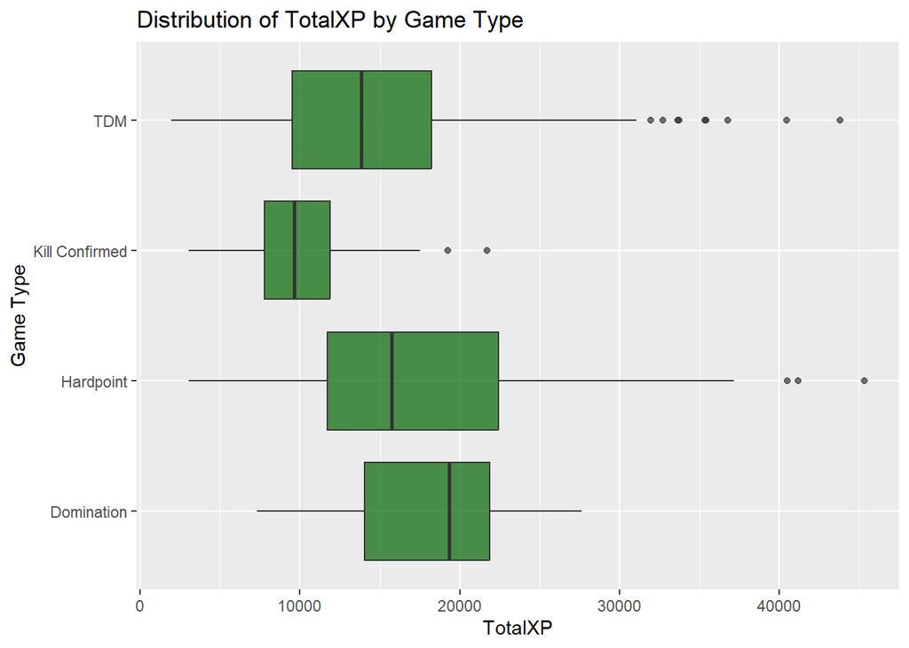

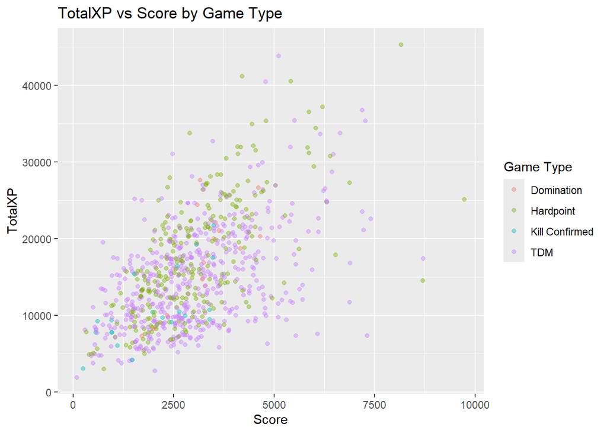

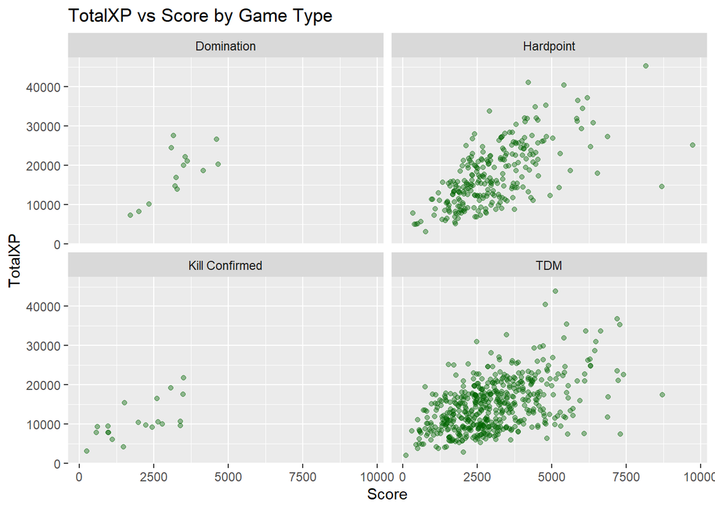

```
##
## Call:
## lm(formula = TotalXP ~ Score + GameType_clean, data = Games_clean_3)
##
## Residuals:
##      Min       1Q   Median       3Q      Max
## -18907.7  -4226.4   -332.6   3902.2  23463.2
##
## Coefficients:
##                                Estimate Std. Error t value Pr(>|t|)
## (Intercept)                   9072.5914  1592.5597   5.697 1.71e-08 ***
## Score                            2.7052     0.1441  18.768  < 2e-16 ***
## GameType_cleanHardpoint        121.7613  1561.2263   0.078   0.9379
## GameType_cleanKill Confirmed -3703.1728  1990.5385  -1.860   0.0632 .
## GameType_cleanTDM            -2570.4367  1540.9337  -1.668   0.0957 .
## ---
## Signif. codes:  0 '***' 0.001 '**' 0.01 '*' 0.05 '.' 0.1 ' ' 1
##
## Residual standard error: 5687 on 803 degrees of freedom
## Multiple R-squared:  0.3377, Adjusted R-squared:  0.3344
## F-statistic: 102.4 on 4 and 803 DF,  p-value: < 2.2e-16
```

```
##
## Call:
## lm(formula = TotalXP ~ Score * GameType_clean, data = Games_clean_3)
##
## Residuals:
##      Min       1Q   Median       3Q      Max
## -23620.1  -4130.1   -152.2   3626.4  24467.6
##
## Coefficients:
##                                    Estimate Std. Error t value Pr(>|t|)
## (Intercept)                         141.168   6140.010   0.023  0.98166
## Score                                 5.413      1.805   2.999  0.00279 **
## GameType_cleanHardpoint            6153.288   6198.660   0.993  0.32117
## GameType_cleanKill Confirmed       4637.698   6695.983   0.693  0.48876
## GameType_cleanTDM                  7788.913   6167.196   1.263  0.20697
## Score:GameType_cleanHardpoint        -1.752      1.823  -0.961  0.33680
## Score:GameType_cleanKill Confirmed   -2.412      2.155  -1.119  0.26344
## Score:GameType_cleanTDM              -3.182      1.813  -1.755  0.07961 .
## ---
## Signif. codes:  0 '***' 0.001 '**' 0.01 '*' 0.05 '.' 0.1 ' ' 1
##
## Residual standard error: 5615 on 800 degrees of freedom
## Multiple R-squared:  0.3568, Adjusted R-squared:  0.3512
## F-statistic: 63.41 on 7 and 800 DF,  p-value: < 2.2e-16
```

```
## Analysis of Variance Table
##
## Model 1: TotalXP ~ Score + GameType_clean
## Model 2: TotalXP ~ Score * GameType_clean
##   Res.Df        RSS Df Sum of Sq      F   Pr(>F)
## 1    803 2.5971e+10
## 2    800 2.5222e+10  3 749021825 7.9194 3.29e-05 ***
## ---
## Signif. codes:  0 '***' 0.001 '**' 0.01 '*' 0.05 '.' 0.1 ' ' 1
```

The modeling results show that Score is the primary determinant of TotalXP, while game type has only a minimal effect once Score is accounted for. In the main-effects model, Score has a strong and highly significant positive association with TotalXP, indicating that players reliably earn more XP as their Score increases. In contrast, the game‑type coefficients, Hardpoint, Kill Confirmed, and TDM—are all small and statistically weak with p‑values of 0.94, 0.063, and 0.096, respectively, suggesting that players with the same Score receive roughly similar TotalXP regardless of the mode they are playing. The interaction model, which allows each game type to have its own Score‑to‑XP slope, fits statistically better (ANOVA p = 3.29e‑05), but the improvement is modest, raising R² only from 0.338 to 0.357, and none of the interaction terms reach conventional significance. The strongest, Score × TDM, has p = 0.079. Overall, the analysis supports a clear conclusion: after controlling for Score, game type has little practical impact on TotalXP, and players’ performance, as measured by Score, is what truly determines how much XP they earn.

## Task 4 (Prediction)

Research Question: How do different classification methods compare for predicting the result of matches.

The `Result` variable contains the score for each match as a character string, with the left number being the player’s team score and the right number being the opposing team’s score. Some data wrangling is necessary to prepare the data for classification. The `Result` variable must be split into `Player_Team_Score` and `Opposing_Team_Score` to compare the scores. A binary variable, `Player_Team_Win`, is created and takes a value of 1 when the player’s team’s score is greater than the opposing team’s score.

In order to fairly compare methods, the same predictor variables must be used for each. The variables `Eliminations`, `Deaths`, `Score`, and `Damage` will be used. These variables were chosen because they relate to the player’s performance during a mathc. Below we can see that `Damage` has a correlation with `Eliminations` which is to be expected as damage is necessary to eliminate an opponent. There is a correlation between `Eliminations` and `Score` as well, but `Score` will be kept as a predictor variable as it appears that more goes into calculating the score than simply the number of eliminations.

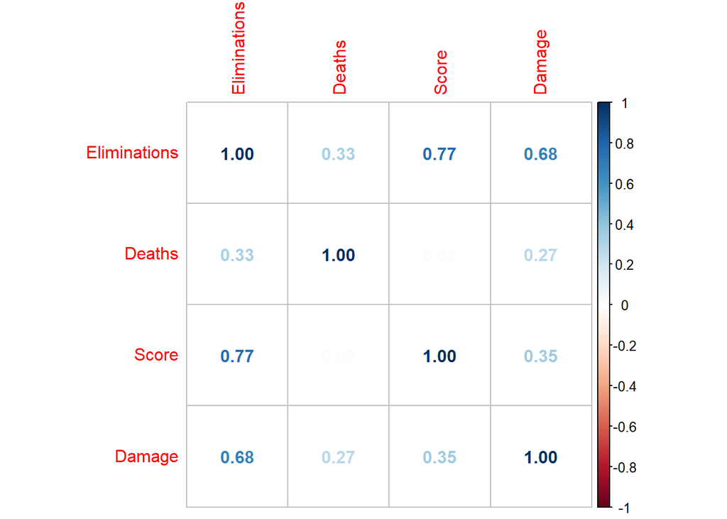

Model prediction power will be compared by splitting the data into an 80/20 testing-training split and seeing how well the model generalizes to new data. AUC and Accuracy will be the values used to compare models.

The three classification methods that will be compared are logistic regression, random forest, and support vector machine. Each model will be created using the training data set. For the logistic regression model we create a generalized linear model with a binomial distribution. For the random forest model we used 500 decision trees as it is enough to decrease the variance, but also not too many to overly increase computation time without gains in accuracy. We selected 2 for the `mtry` parameter or the number of predictor variables considered at each split within the tree as it is the default to choose the square root of the number of predictors which in our case was 4. Our third classification method was Support vector machine (SVM). SVM is a machine learning technique with the goal of finding the best possible boundary that separates the classes. Since we chose multiple predictors the boundary between predicting win or loss is a multidimensional plane.

The predictions for each model are calculated by inputing the test data predictor variables into the models.

Below we can see the ROC curves for each method. From these plots we can see that the curves are somewhat similar and there does not appear to be a clear superior or inferior prediction method.

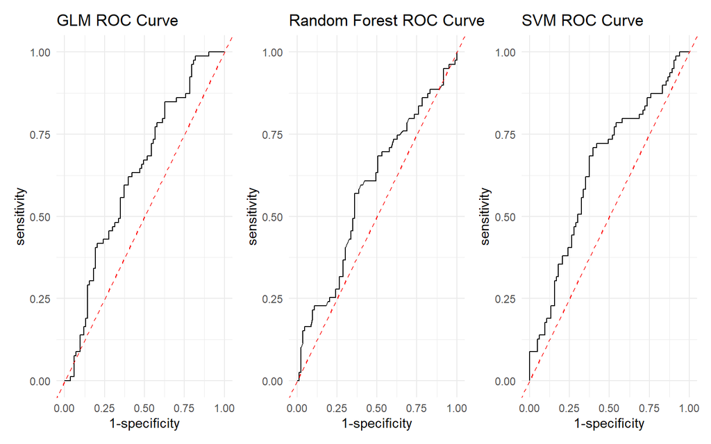

| Method | Accuracy | AUC |
| --- | --- | --- |
| GLM | 0.5740741 | 0.6303187 |
| Random Forst | 0.5987654 | 0.5834986 |
| SVM | 0.5987654 | 0.6423669 |

From this table we can see that none of the methods were exceptional at predicting whether the player’s team wins based on player performance. We can conclude that SVM was the best prediction method in this case as it has both the highest accuracy and area under the curve.

## Contributions

Task 1: Isaac Swope  
Task 2: Andrew Loiselle  
Task 3: Andrew Loiselle  
Task 4: Isaac Swope

## Code Appendix

```r
knitr::opts_chunk$set(echo = FALSE, warning = FALSE)

rm(list = ls())

# Libraries

library(tidyverse)
library(kableExtra)
library(dplyr)
library(tidyr)
library(ggplot2)
library(stringr)
library(pROC)
library(patchwork)
library(corrplot)
library(randomForest)
library(e1071)

# Reading in Data

GamesPlayer1 <- read.csv("https://raw.githubusercontent.com/Swopei/STAT380FinalProj_repo/refs/heads/main/Data/CODGames_p1_380.csv")
GamesPlayer2 <- read.csv("https://raw.githubusercontent.com/Swopei/STAT380FinalProj_repo/refs/heads/main/Data/CODGames_p2_380.csv")
Modes <- read.csv("https://raw.githubusercontent.com/Swopei/STAT380FinalProj_repo/refs/heads/main/Data/CODGameModes.csv")
Maps <- read.csv("https://raw.githubusercontent.com/Swopei/STAT380FinalProj_repo/refs/heads/main/Data/CODMaps.csv")

# Data Wrangling / Cleaning for Task 1

GamesPlayer1$Player = "Player1"
GamesPlayer2$Player = "Player2"
Games <- bind_rows(GamesPlayer1, GamesPlayer2)

Games_votes <- Games %>%
  separate(MapVote,
           into = c("Map1Vote", "Map2Vote"),
           sep = " to ") %>%
  filter(Map1Vote != Map2Vote) %>%
  mutate(across(c(Map1, Map2, Choice), ~str_to_lower(str_squish(.))))

Maps$Name <- str_to_lower(Maps$Name)

Option1 <- Games_votes %>%
  group_by(Map1) %>%
  summarise(
    frequency1 = n()
  )

Option2 <- Games_votes %>%
  group_by(Map2) %>%
  summarise(
    frequency2 = n()
  )

OptionWin <-Games_votes %>%
  group_by(Choice) %>%
  summarise(
    vote_win = n()
  )

Map_table <- Option1 %>%
  full_join(Option2, by = c("Map1" = "Map2")) %>%
  full_join(OptionWin, by = c("Map1" = "Choice")) %>%
  mutate(across(everything(), ~replace_na(., 0)),
    candidate_count = frequency1 + frequency2,
    map = Map1,
    vote_win_proportion = round(vote_win/candidate_count, 4)
    ) %>%
  right_join(Maps, by = c("map" = "Name")) %>%
  select(map, candidate_count, vote_win, vote_win_proportion)

# Creating Task 1 table

kable(Map_table)

# Creating Task 1 column plot

ggplot(data = Map_table,
       mapping = aes(x = reorder(map, vote_win_proportion), y = vote_win_proportion)) +
  geom_col(fill = "darkgreen") +
  theme(
    axis.text.x = element_text(angle = 60, vjust = 1, hjust = 1, size = 10)
  ) +
  labs(title = "Proportions of Map Vote Wins", x = "Map", y = "Proportion of Votes Won")

# Combine Player 1 and Player 2 data
games_ai <- bind_rows(GamesPlayer1, GamesPlayer2)

# Remove games where the player joined after the vote (Map1 and Map2 both missing)
games_clean <- games_ai %>%
  filter(!(is.na(Map1) & is.na(Map2)))

games_clean <- games_clean %>%
  mutate(
    # Identify vote outcomes
    map1_votes = ifelse(MapVote == "Map1", 1, 0),
    map2_votes = ifelse(MapVote == "Map2", 1, 0),

    # Determine winner (Choice already gives this, but we need tie logic)
    winner = Choice
  )

map_options <- games_clean %>%
  select(Map1, Map2, winner) %>%
  pivot_longer(cols = c(Map1, Map2),
               names_to = "Position",
               values_to = "Map") %>%
  filter(!is.na(Map))

map_summary <- map_options %>%
  group_by(Map) %>%
  summarise(
    appearances = n(),
    wins = sum(Map == winner),
    win_rate = wins / appearances
  ) %>%
  arrange(desc(win_rate))

print(map_summary)

ggplot(map_summary, aes(x = reorder(Map, win_rate), y = win_rate)) +
  geom_col(fill = "steelblue") +
  coord_flip() +
  labs(
    title = "Probability a Map Wins When It Is an Option",
    x = "Map",
    y = "Win Rate"
  ) +
  scale_y_continuous(labels = scales::percent_format())

Games_clean_3 <- Games %>%
  mutate(
    GameType = str_squish(GameType),
    GameType_clean = str_remove(GameType, "^HC\\s*-\\s*")
  ) %>%
  filter(!is.na(TotalXP), !is.na(Score), !is.na(GameType_clean))

summary_stats <- Games_clean_3 %>%
  group_by(GameType_clean) %>%
  summarise(
    n = n(),
    mean_TotalXP = mean(TotalXP, na.rm = TRUE),
    sd_TotalXP = sd(TotalXP, na.rm = TRUE),
    mean_Score = mean(Score, na.rm = TRUE),
    sd_Score = sd(Score, na.rm = TRUE)
  )

print(summary_stats)
ggplot(Games_clean_3, aes(x = GameType_clean, y = TotalXP)) +
  geom_boxplot(fill = "darkgreen", alpha = 0.7) +
  coord_flip() +
  labs(
    title = "Distribution of TotalXP by Game Type",
    x = "Game Type",
    y = "TotalXP"
  )
ggplot(Games_clean_3, aes(x = Score, y = TotalXP, color = GameType_clean)) +
  geom_point(alpha = 0.4) +
  labs(
    title = "TotalXP vs Score by Game Type",
    x = "Score",
    y = "TotalXP",
    color = "Game Type"
  )
ggplot(Games_clean_3, aes(x = Score, y = TotalXP)) +
  geom_point(alpha = 0.4, color = "darkgreen") +
  facet_wrap(~ GameType_clean) +
  labs(
    title = "TotalXP vs Score by Game Type",
    x = "Score",
    y = "TotalXP"
  )
Games_clean_3$GameType_clean <- factor(Games_clean_3$GameType_clean)

model_main <- lm(TotalXP ~ Score + GameType_clean, data = Games_clean_3)
summary(model_main)

model_interaction <- lm(TotalXP ~ Score * GameType_clean, data = Games_clean_3)
summary(model_interaction)

anova(model_main, model_interaction)
# Data Wrangling for Task 4

GamesResults <- Games %>%
  separate(Result,
           into = c("Player_Team_Score", "Opposing_Team_Score"),
           sep = "-",
  ) %>%
  mutate(Player_Team_Win = as.factor(ifelse(Player_Team_Score > Opposing_Team_Score, 1, 0)))

x_vars <- c("Eliminations", "Deaths", "Score", "Damage")
GamesResults <- GamesResults %>%
  drop_na(all_of(x_vars))
CorMat <- cor(GamesResults[ , x_vars], method = "pearson")
corrplot(CorMat, method = "number")
# Testing-Training split for Task 4

set.seed(146)
train_ind <- sample(1:nrow(GamesResults), floor(0.8*nrow(GamesResults)))
set.seed(NULL)
Train <- GamesResults[train_ind,]
Test <- GamesResults[-train_ind,]



# Creating models for Task 4

Glmodel <- glm(Player_Team_Win ~ Eliminations + Deaths + Score + Damage, family = "binomial", data = Train)

set.seed(146)
Rfmodel <- randomForest(Player_Team_Win ~ Eliminations + Deaths + Score + Damage, data = Train, ntree = 500, mtry = 2)
set.seed(NULL)

Svmmodel <- svm(Player_Team_Win ~ Eliminations + Deaths + Score + Damage, data = Train, probability = TRUE, scale = TRUE)

# Model predictions and accuracy for Task 4

glm_probs <- predict(Glmodel, newdata = Test, type = "response")
rf_probs <- predict(Rfmodel, newdata = Test, type = "prob")
rf_probs <- rf_probs[ , 2]
test_predictors <- Test[, c("Eliminations", "Deaths", "Score", "Damage")]
svm_probs_raw <- predict(Svmmodel, newdata = test_predictors, probability = TRUE)
svm_probs <- attr(svm_probs_raw, "probabilities")[, "1"]

glm_preds <- ifelse(glm_probs > 0.5, 1, 0)
rf_preds <- ifelse(rf_probs > 0.5, 1, 0)
svm_preds <- ifelse(svm_probs > 0.5, 1, 0)

glm_accuracy <- mean(glm_preds == Test$Player_Team_Win)
rf_accuracy <- mean(rf_preds == Test$Player_Team_Win)
svm_accuracy <- mean(svm_preds == Test$Player_Team_Win)

# Creating the ROC curves and getting the AUC values for Task 4

glm_roc <- roc(response = Test$Player_Team_Win,
                predictor = glm_probs,
                print.auc = TRUE,
                legacy.axes = TRUE)
glm_auc <- as.numeric(glm_roc$auc)
glm_roc_plot <- ggroc(glm_roc, legacy.axes = TRUE) +
  geom_abline(intercept = 0, slope = 1, linetype = "dashed", color = "red") +
  labs(title = "GLM ROC Curve") +
  theme_minimal()

rf_roc <- roc(response = Test$Player_Team_Win,
                predictor = rf_probs,
                print.auc = TRUE,
                legacy.axes = TRUE)
rf_auc <- as.numeric(rf_roc$auc)
rf_roc_plot <- ggroc(rf_roc, legacy.axes = TRUE) +
  geom_abline(intercept = 0, slope = 1, linetype = "dashed", color = "red") +
  labs(title = "Random Forest ROC Curve") +
  theme_minimal()

svm_roc <- roc(response = Test$Player_Team_Win,
                predictor = svm_probs,
                print.auc = TRUE,
                legacy.axes = TRUE)
svm_auc <- as.numeric(svm_roc$auc)
svm_roc_plot <- ggroc(svm_roc, legacy.axes = TRUE) +
  geom_abline(intercept = 0, slope = 1, linetype = "dashed", color = "red") +
  labs(title = "SVM ROC Curve") +
  theme_minimal()

glm_roc_plot + rf_roc_plot + svm_roc_plot

# Creating method comparison table for Task 4

Method_table <- data.frame(
  Method = c("GLM", "Random Forst", "SVM"),
  Accuracy = c(glm_accuracy, rf_accuracy, svm_accuracy),
  AUC = c(glm_auc, rf_auc, svm_auc)
)

kable(Method_table)
```